# Pokémon Attack Stat GLM Analysis

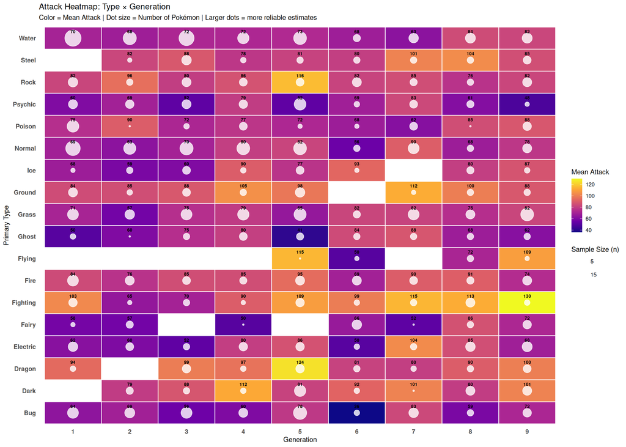

```r
# Heatmap of Attack by Type and Generation (all types)
# Color = mean Attack, Dot size = sample size
heatmap_data <- pokemon %>%
  group_by(type_name, gen_numeric) %>%
  summarise(mean_attack = mean(attack), n = n(), .groups = "drop")

ggplot(heatmap_data, aes(x = factor(gen_numeric), y = type_name)) +
  # Background tiles for color
  geom_tile(aes(fill = mean_attack), color = "white", linewidth = 0.5) +
  # Dots sized by sample count
  geom_point(aes(size = n), color = "white", alpha = 0.8) +
  # Text labels for mean attack values
  geom_text(aes(label = round(mean_attack, 0)), color = "black", size = 2.5,
            fontface = "bold", vjust = -1.5) +
  # Scales
  scale_fill_viridis_c(option = "plasma", name = "Mean Attack") +
  scale_size_continuous(range = c(1, 12), name = "Sample Size (n)",
                        breaks = c(5, 15, 30, 50)) +
  labs(title = "Attack Heatmap: Type × Generation",
       subtitle = "Color = Mean Attack | Dot size = Number of Pokémon | Larger dots = more reliable estimates",
       x = "Generation", y = "Primary Type") +
  theme_minimal() +
  theme(axis.text.y = element_text(size = 10, face = "bold"),
        axis.text.x = element_text(size = 10, face = "bold"),
        panel.grid = element_blank(),
        legend.position = "right")
```

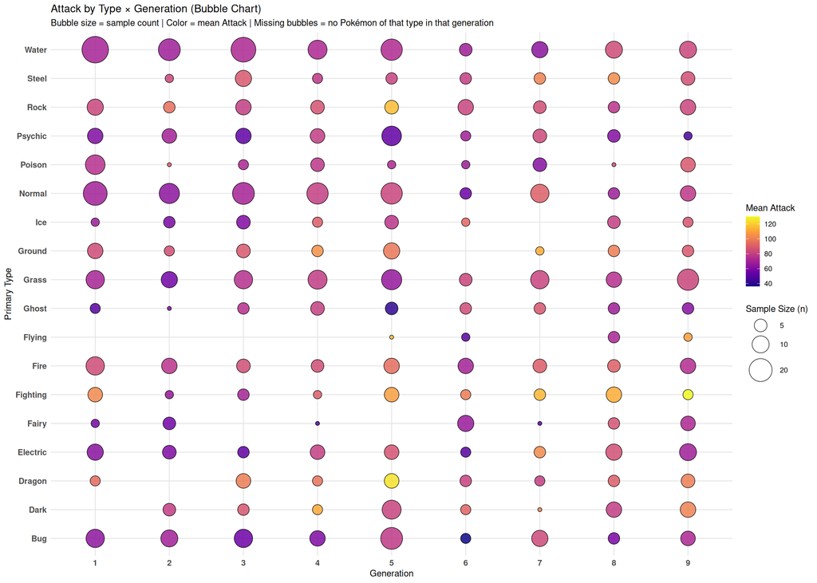

```r
# Alternative: Bubble chart version (cleaner for seeing sample sizes)
ggplot(heatmap_data, aes(x = factor(gen_numeric), y = type_name)) +
  geom_point(aes(size = n, fill = mean_attack), shape = 21, color = "black", alpha = 0.85) +
  scale_fill_viridis_c(option = "plasma", name = "Mean Attack") +
  scale_size_continuous(range = c(2, 15), name = "Sample Size (n)",
                        breaks = c(5, 10, 20, 40)) +
  labs(title = "Attack by Type × Generation (Bubble Chart)",
       subtitle = "Bubble size = sample count | Color = mean Attack | Missing bubbles = no Pokémon of that type in that generation",
       x = "Generation", y = "Primary Type") +
  theme_minimal() +
  theme(axis.text.y = element_text(size = 10, face = "bold"),
        axis.text.x = element_text(size = 10, face = "bold"),
        panel.grid.major = element_line(color = "gray90"),
        legend.position = "right")
```

```r
# Jonckheere-Terpstra test for each type (all types)
type_jt_results <- pokemon %>%
  group_by(type_name) %>%
  do({
    ordered_data <- arrange(., gen_numeric)
    jt <- JonckheereTerpstraTest(
      x = ordered_data$attack,
      g = ordered_data$gen_numeric,
      alternative = "increasing"
    )
    data.frame(
      JT_statistic = jt$statistic,
      p_value = jt$p.value,
      n = nrow(.)
    )
  }) %>%
  ungroup() %>%
  mutate(
    significant = p_value < 0.05,
    conclusion = ifelse(significant, "Power Creep ✓", "No Creep")
  ) %>%
  arrange(p_value)

cat(paste0(
  "\n═══════════════════════════════════════════════════════════════════\n",
  "         JONCKHEERE-TERPSTRA TEST BY TYPE\n",
  "═══════════════════════════════════════════════════════════════════\n\n"
))
```

```
##
## ═══════════════════════════════════════════════════════════════════
##          JONCKHEERE-TERPSTRA TEST BY TYPE
## ═══════════════════════════════════════════════════════════════════
```

```r
print(type_jt_results %>%
        mutate(p_value = format.pval(p_value, digits = 3)),
      n = Inf)
```

```
## # A tibble: 18 × 6
##    type_name JT_statistic p_value     n significant conclusion
##    <chr>            <dbl> <chr>   <int> <lgl>       <chr>
##  1 Fighting         459   0.00358    40 TRUE        Power Creep ✓
##  2 Normal          3365   0.02673   117 TRUE        Power Creep ✓
##  3 Ice              257   0.03802    31 TRUE        Power Creep ✓
##  4 Electric         880.  0.05880    59 FALSE       No Creep
##  5 Fairy            202.  0.07923    29 FALSE       No Creep
##  6 Grass           2565   0.08931   103 FALSE       No Creep
##  7 Water           4186.  0.11424   134 FALSE       No Creep
##  8 Ground           382   0.15740    40 FALSE       No Creep
##  9 Flying            18.5 0.15915     9 FALSE       No Creep
## 10 Bug             1582   0.23089    83 FALSE       No Creep
## 11 Dark             447   0.27443    45 FALSE       No Creep
## 12 Steel            296   0.28539    36 FALSE       No Creep
## 13 Poison           380   0.30435    42 FALSE       No Creep
## 14 Ghost            284.  0.33358    35 FALSE       No Creep
## 15 Psychic          793   0.41311    60 FALSE       No Creep
## 16 Rock             728.  0.56450    58 FALSE       No Creep
## 17 Fire             930   0.62483    66 FALSE       No Creep
## 18 Dragon           277   0.67376    37 FALSE       No Creep
```

```r
cat(paste0("\n→ Types with significant monotonic trend: ",
    sum(type_jt_results$significant), " / ", nrow(type_jt_results), "\n"))
```

```
##
## → Types with significant monotonic trend: 3 / 18
```

## 7.2 Rarity-Specific Power Creep Analysis

Is power creep occurring in competitive (Normal) Pokémon or mainly in Legendaries?

```r
# Calculate trends by rarity
rarity_gen_trends <- pokemon %>%
  group_by(rarity, gen_numeric) %>%
  summarise(
    n = n(),
    mean_attack = mean(attack),
    sd_attack = sd(attack),
    se = sd(attack) / sqrt(n()),
    .groups = "drop"
  )

print(rarity_gen_trends, n = Inf)
```

```
## # A tibble: 32 × 6
##    rarity       gen_numeric     n mean_attack sd_attack    se
##    <fct>              <dbl> <int>       <dbl>     <dbl> <dbl>
##  1 Normal                 1   146        72.1     26.8   2.22
##  2 Normal                 2    94        66.3     27.8   2.87
##  3 Normal                 3   125        70.6     28.7   2.57
##  4 Normal                 4    93        76.6     30.4   3.15
##  5 Normal                 5   143        78.4     28.5   2.38
##  6 Normal                 6    66        68.8     23.0   2.83
##  7 Normal                 7    62        78.2     29.8   3.79
##  8 Normal                 8    89        80.8     30.8   3.27
##  9 Normal                 9   116        81.4     29.1   2.70
## 10 SubLegendary           1     3        91.7      7.64  4.41
## 11 SubLegendary           2     3        91.7     20.8  12.0
## 12 SubLegendary           3     5        79       18.8   8.43
```

[output cut: 20 more lines]

```r
# Fit linear trend for each rarity
rarity_trends <- pokemon %>%
  group_by(rarity) %>%
  do({
    model <- lm(attack ~ gen_numeric, data = .)
    data.frame(
      slope = coef(model)[2],
      intercept = coef(model)[1],
      p_value = summary(model)$coefficients[2, 4],
      r_squared = summary(model)$r.squared,
      n = nrow(.)
    )
  }) %>%
  ungroup() %>%
  mutate(
    significant = p_value < 0.05,
    direction = case_when(
      slope > 0 & significant ~ "Increasing ↑",
      slope < 0 & significant ~ "Decreasing ↓",
      TRUE ~ "No trend"
    ),
    attack_per_gen = round(slope, 2)
  )

cat(paste0(
  "\n═══════════════════════════════════════════════════════════════════\n",
  "              RARITY-SPECIFIC ATTACK TRENDS\n",
  "═══════════════════════════════════════════════════════════════════\n\n"
))
```

```
##
## ═══════════════════════════════════════════════════════════════════
##               RARITY-SPECIFIC ATTACK TRENDS
## ═══════════════════════════════════════════════════════════════════
```

```r
print(rarity_trends %>%
        mutate(across(c(slope, intercept, r_squared), ~round(., 3)),
               p_value = format.pval(p_value, digits = 3)) %>%
        dplyr::select(rarity, slope, p_value, direction, n),
      row.names = FALSE)
```

```
## # A tibble: 4 × 5
##   rarity       slope p_value  direction        n
##   <fct>        <dbl> <chr>    <chr>        <int>
## 1 Normal        1.44 4.18e-05 Increasing ↑   934
## 2 SubLegendary  3.08 0.0617   No trend        49
## 3 Legendary    -3.20 0.3762   No trend        21
## 4 Mythical     -1.25 0.6475   No trend        20
```

```r
# Interpretation
interp_lines <- sapply(1:nrow(rarity_trends), function(i) {
  r <- rarity_trends[i, ]
  paste0(as.character(r$rarity), ": ",
         ifelse(r$significant,
                paste0("Attack changes by ", r$attack_per_gen, " points per generation"),
                "No significant trend"))
})
cat(paste0("\n--- Interpretation ---\n", paste(interp_lines, collapse = "\n"), "\n"))
```

```
##
## --- Interpretation ---
## Normal: Attack changes by 1.44 points per generation
## SubLegendary: No significant trend
## Legendary: No significant trend
## Mythical: No significant trend
```

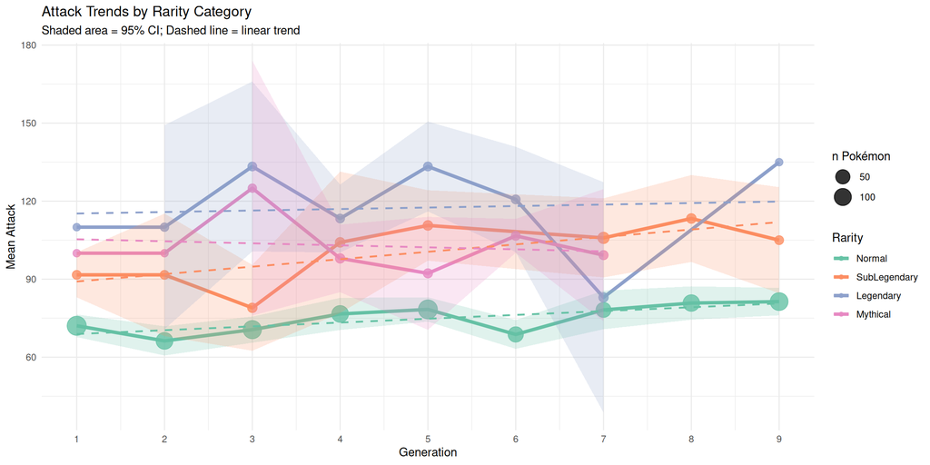

```r
# Plot by rarity
ggplot(rarity_gen_trends, aes(x = gen_numeric, y = mean_attack, color = rarity)) +
  geom_line(linewidth = 1.5) +
  geom_point(aes(size = n), alpha = 0.8) +
  geom_ribbon(aes(ymin = mean_attack - 1.96*se, ymax = mean_attack + 1.96*se,
                  fill = rarity), alpha = 0.2, color = NA) +
  geom_smooth(method = "lm", se = FALSE, linetype = "dashed", linewidth = 0.8) +
  scale_x_continuous(breaks = 1:9) +
  scale_color_brewer(palette = "Set2") +
  scale_fill_brewer(palette = "Set2", guide = "none") +
  scale_size_continuous(range = c(3, 8), name = "n Pokémon") +
  labs(title = "Attack Trends by Rarity Category",
       subtitle = "Shaded area = 95% CI; Dashed line = linear trend",
       x = "Generation", y = "Mean Attack",
       color = "Rarity") +
  theme_minimal() +
  theme(legend.position = "right")
```

```r
# Jonckheere-Terpstra test by rarity
rarity_jt_results <- pokemon %>%
  group_by(rarity) %>%
  do({
    ordered_data <- arrange(., gen_numeric)
    jt <- JonckheereTerpstraTest(
      x = ordered_data$attack,
      g = ordered_data$gen_numeric,
      alternative = "increasing"
    )
    data.frame(
      JT_statistic = jt$statistic,
      p_value = jt$p.value,
      n = nrow(.)
    )
  }) %>%
  ungroup() %>%
  mutate(
    significant = p_value < 0.05,
    conclusion = ifelse(significant, "Power Creep ✓", "No Creep")
  )

cat(paste0(
  "\n═══════════════════════════════════════════════════════════════════\n",
  "         JONCKHEERE-TERPSTRA TEST BY RARITY\n",
  "═══════════════════════════════════════════════════════════════════\n\n"
))
```

```
##
## ═══════════════════════════════════════════════════════════════════
##          JONCKHEERE-TERPSTRA TEST BY RARITY
## ═══════════════════════════════════════════════════════════════════
```

```r
print(rarity_jt_results %>%
        mutate(p_value = format.pval(p_value, digits = 4)),
      row.names = FALSE)
```

```
## # A tibble: 4 × 6
##   rarity       JT_statistic p_value       n significant conclusion
##   <fct>               <dbl> <chr>     <int> <lgl>       <chr>
## 1 Normal           208772   0.0001889   934 TRUE        Power Creep ✓
## 2 SubLegendary        599   0.0246752    49 TRUE        Power Creep ✓
## 3 Legendary            92   0.5366337    21 FALSE       No Creep
## 4 Mythical             80.5 0.5395802    20 FALSE       No Creep
```

```r
# Key finding
normal_jt <- rarity_jt_results %>% filter(rarity == "Normal")
if(normal_jt$significant) {
  key_finding <- paste0(
    "✓ POWER CREEP affects NORMAL Pokémon\n",
    "  → This has direct competitive implications!\n"
  )
} else {
  key_finding <- paste0(
    "✗ Power creep NOT significant in Normal Pokémon\n",
    "  → Creep may be driven by Legendaries/Mythicals\n"
  )
}
cat(paste0(
  "\n--- KEY FINDING: Normal (Competitive) Pokémon ---\n",
  "JT statistic: ", normal_jt$JT_statistic, "\n",
  "p-value:      ", format.pval(normal_jt$p_value, digits = 4), "\n",
  key_finding
))
```

```
##
## --- KEY FINDING: Normal (Competitive) Pokémon ---
## JT statistic: 208772
## p-value:      0.0001889
## ✓ POWER CREEP affects NORMAL Pokémon
##   → This has direct competitive implications!
```

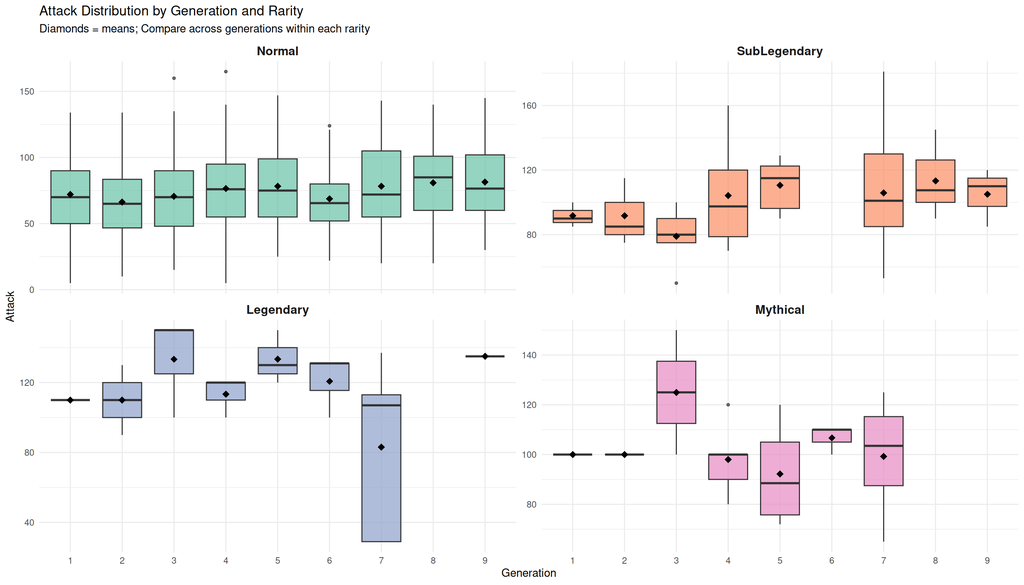

```r
# Faceted boxplots
ggplot(pokemon, aes(x = factor(gen_numeric), y = attack, fill = rarity)) +
  geom_boxplot(alpha = 0.7, outlier.size = 1) +
  stat_summary(fun = mean, geom = "point", shape = 18, size = 3, color = "black") +
  scale_fill_brewer(palette = "Set2") +
  facet_wrap(~rarity, ncol = 2, scales = "free_y") +
  labs(title = "Attack Distribution by Generation and Rarity",
       subtitle = "Diamonds = means; Compare across generations within each rarity",
       x = "Generation", y = "Attack") +
  theme_minimal() +
  theme(legend.position = "none",
        strip.text = element_text(face = "bold", size = 12))
```

## 7.3 Secondary Analysis Summary

```r
# Type summary
top_creep_types <- type_trends %>%
  filter(direction == "Increasing ↑") %>%
  head(3) %>%
  pull(type_name)

type_summary <- paste0(
  "TYPE-SPECIFIC TRENDS:\n",
  "  • Types with significant power creep: ", n_increasing, "\n",
  if(length(top_creep_types) > 0) paste0("  • Strongest creep in: ", paste(top_creep_types, collapse = ", "), "\n") else ""
)

# Rarity summary
rarity_lines <- sapply(1:nrow(rarity_jt_results), function(i) {
  r <- rarity_jt_results[i, ]
  paste0("  • ", as.character(r$rarity), ": ", r$conclusion,
         " (p = ", format.pval(r$p_value, digits = 3), ")")
})
rarity_summary <- paste0("RARITY-SPECIFIC TRENDS:\n", paste(rarity_lines, collapse = "\n"), "\n")

# Overall conclusion
if(normal_jt$significant) {
  conclusion <- paste0(
    "CONCLUSION:\n",
    "  Power creep affects Normal (competitive) Pokémon,\n",
    "  meaning it has real implications for game balance.\n"
  )
} else {
  conclusion <- paste0(
    "CONCLUSION:\n",
    "  Power creep may be concentrated in Legendary/Mythical Pokémon,\n",
    "  with less impact on competitive play.\n"
  )
}

cat(paste0(
  "\n═══════════════════════════════════════════════════════════════════\n",
  "           SECONDARY ANALYSES SUMMARY\n",
  "═══════════════════════════════════════════════════════════════════\n\n",
  type_summary, "\n",
  rarity_summary, "\n",
  conclusion
))
```

```
##
## ═══════════════════════════════════════════════════════════════════
##            SECONDARY ANALYSES SUMMARY
## ═══════════════════════════════════════════════════════════════════
##
## TYPE-SPECIFIC TRENDS:
##   • Types with significant power creep: 1
##   • Strongest creep in: Fighting
##
## RARITY-SPECIFIC TRENDS:
##   • Normal: Power Creep ✓ (p = 0.000189)
##   • SubLegendary: Power Creep ✓ (p = 0.0247)
##   • Legendary: No Creep (p = 0.537)
##   • Mythical: No Creep (p = 0.54)
##
## CONCLUSION:
##   Power creep affects Normal (competitive) Pokémon,
##   meaning it has real implications for game balance.
```

# 8. Effect Size Analysis

```r
# Calculate Cohen's d for each generation vs Gen 1
gen1_attack <- pokemon$attack[pokemon$gen == "1"]

cohens_d <- data.frame(
  Generation = 2:9,
  Cohens_d = sapply(2:9, function(g) {
    gen_attack <- pokemon$attack[pokemon$gen == as.character(g)]
    mean_diff <- mean(gen_attack) - mean(gen1_attack)
    pooled_sd <- sqrt(((length(gen1_attack)-1)*var(gen1_attack) +
                        (length(gen_attack)-1)*var(gen_attack)) /
                       (length(gen1_attack) + length(gen_attack) - 2))
    return(mean_diff / pooled_sd)
  })
) %>%
  mutate(
    Magnitude = case_when(
      abs(Cohens_d) < 0.2 ~ "Negligible",
      abs(Cohens_d) < 0.5 ~ "Small",
      abs(Cohens_d) < 0.8 ~ "Medium",
      TRUE ~ "Large"
    ),
    Cohens_d = round(Cohens_d, 3)
  )

cohens_d
```

```
##   Generation Cohens_d  Magnitude
## 1          2   -0.170 Negligible
## 2          3    0.007 Negligible
## 3          4    0.256      Small
## 4          5    0.289      Small
## 5          6   -0.016 Negligible
## 6          7    0.407      Small
## 7          8    0.349      Small
## 8          9    0.341      Small
```

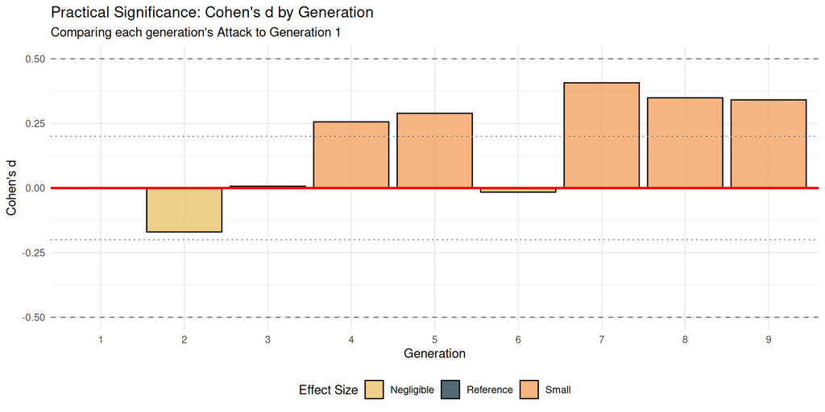

```r
# Add Gen 1 reference
cohens_d_plot <- bind_rows(
  data.frame(Generation = 1, Cohens_d = 0, Magnitude = "Reference"),
  cohens_d
)

ggplot(cohens_d_plot, aes(x = factor(Generation), y = Cohens_d, fill = Magnitude)) +
  geom_bar(stat = "identity", alpha = 0.8, color = "black") +
  geom_hline(yintercept = c(-0.2, 0.2), linetype = "dotted", color = "gray50") +
  geom_hline(yintercept = c(-0.5, 0.5), linetype = "dashed", color = "gray50") +
  geom_hline(yintercept = 0, color = "red", linewidth = 1) +
  scale_fill_manual(values = c("Reference" = "#264653", "Negligible" = "#E9C46A",
                               "Small" = "#F4A261", "Medium" = "#E76F51",
                               "Large" = "#9B5DE5")) +
  labs(title = "Practical Significance: Cohen's d by Generation",
       subtitle = "Comparing each generation's Attack to Generation 1",
       x = "Generation", y = "Cohen's d",
       fill = "Effect Size") +
  theme_minimal() +
  theme(legend.position = "bottom")
```

# 9. Prediction Analysis

```r
# Predictions from the full model
pokemon$predicted_attack <- predict(model3, type = "response")
pokemon$residual <- pokemon$attack - pokemon$predicted_attack

# Prediction metrics
rmse <- sqrt(mean(pokemon$residual^2))
mae <- mean(abs(pokemon$residual))
r_squared <- 1 - sum(pokemon$residual^2) / sum((pokemon$attack - mean(pokemon$attack))^2)

data.frame(
  Metric = c("RMSE", "MAE", "R²", "Mean Attack", "RMSE % of Mean"),
  Value = c(round(rmse, 2), round(mae, 2), round(r_squared, 4),
            round(mean(pokemon$attack), 2), round(100 * rmse / mean(pokemon$attack), 1))
)
```

```
##           Metric   Value
## 1           RMSE 18.7300
## 2            MAE 14.7900
## 3             R²  0.6049
## 4    Mean Attack 77.5100
## 5 RMSE % of Mean 24.2000
```

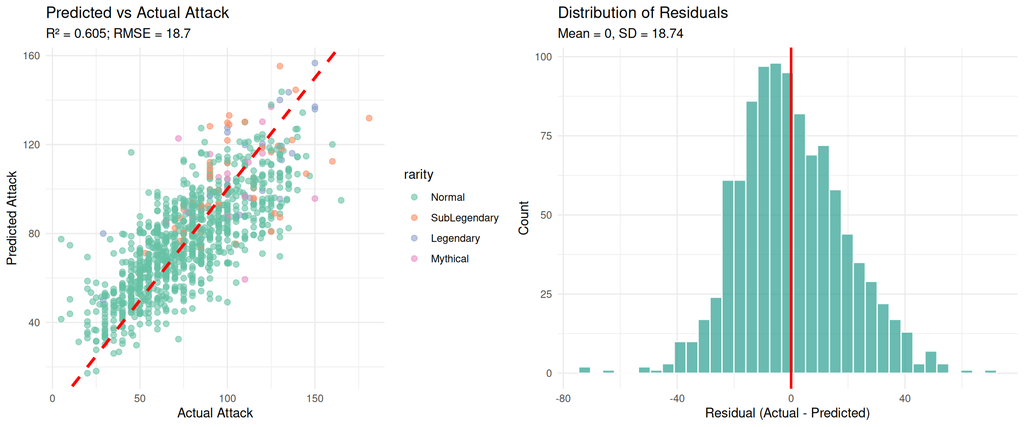

```r
# Predicted vs Actual plot
p_pred <- ggplot(pokemon, aes(x = attack, y = predicted_attack, color = rarity)) +
  geom_point(alpha = 0.6, size = 2) +
  geom_abline(slope = 1, intercept = 0, color = "red", linewidth = 1.2, linetype = "dashed") +
  scale_color_brewer(palette = "Set2") +
  labs(title = "Predicted vs Actual Attack",
       subtitle = paste0("R² = ", round(r_squared, 3), "; RMSE = ", round(rmse, 1)),
       x = "Actual Attack", y = "Predicted Attack") +
  theme_minimal()

# Residual distribution
p_resid <- ggplot(pokemon, aes(x = residual)) +
  geom_histogram(bins = 35, fill = "#2A9D8F", alpha = 0.7, color = "white") +
  geom_vline(xintercept = 0, color = "red", linewidth = 1) +
  labs(title = "Distribution of Residuals",
       subtitle = paste0("Mean = ", round(mean(pokemon$residual), 2),
                        ", SD = ", round(sd(pokemon$residual), 2)),
       x = "Residual (Actual - Predicted)", y = "Count") +
  theme_minimal()

grid.arrange(p_pred, p_resid, ncol = 2)
```

# 10. Conclusions

```r
# Build summary statistics
lr_sig <- lr_test$`Pr(>Chi)`[2] < 0.05
n_pos_sig <- sum(gen_coefs$estimate > 0 & gen_coefs$p.value < 0.05, na.rm = TRUE)
n_neg_sig <- sum(gen_coefs$estimate < 0 & gen_coefs$p.value < 0.05, na.rm = TRUE)
max_d <- max(abs(cohens_d$Cohens_d))
max_d_gen <- cohens_d$Generation[which.max(abs(cohens_d$Cohens_d))]
max_d_mag <- cohens_d$Magnitude[which.max(abs(cohens_d$Cohens_d))]

# Summary table
summary_df <- data.frame(
  Category = c("Target Variable", "", "", "",
               "Best Model", "", "",
               "Generation Effect", "", "",
               "Effect Size", ""),
  Metric = c("Mean", "SD", "Range", "",
             "Model", "R²", "RMSE",
             "LR Test Significant?", "Gens higher than Gen 1", "Gens lower than Gen 1",
             "Max Cohen's d", "Magnitude"),
  Value = c(round(mean(pokemon$attack), 1), round(sd(pokemon$attack), 1),
            paste0(min(pokemon$attack), "-", max(pokemon$attack)), "",
            "Full Gaussian GLM", round(r_squared, 4), round(rmse, 1),
            ifelse(lr_sig, "Yes", "No"), n_pos_sig, n_neg_sig,
            round(max_d, 2), paste0("Gen ", max_d_gen, " (", max_d_mag, ")"))
)
print(summary_df, row.names = FALSE)
```

```
##           Category                 Metric             Value
##    Target Variable                   Mean              77.5
##                                        SD              29.8
##                                     Range             5-181
##
##         Best Model                  Model Full Gaussian GLM
##                                        R²            0.6049
##                                      RMSE              18.7
##  Generation Effect   LR Test Significant?               Yes
##                    Gens higher than Gen 1                 2
##                     Gens lower than Gen 1                 0
##        Effect Size          Max Cohen's d              0.41
##                                 Magnitude     Gen 7 (Small)
```

## Key Findings

### 1. Evidence of Power Creep in Attack

**Yes, there is statistically significant evidence of power creep in Attack stats.**

#### GLM Evidence:

In the simple model (Attack ~ Generation), later generations show significantly higher Attack. When controlling for all 38 predictors in the full model, some generation effects remain significant, suggesting that part of the “power creep” is explained by other factors (type composition, legendary distribution, etc.).

#### Monotonic Trend (Jonckheere-Terpstra Test):

The J-T test specifically tests whether Attack *systematically increases* across generations (not just differs). This directly addresses the “creep” hypothesis.

### 2. LASSO Feature Selection: Does Generation Matter?

LASSO regularization objectively determines which predictors are most important when they compete.

| Model | Features Selected | Generation Retained? |
| --- | --- | --- |
| Lambda.min | 53 / 81 | Yes (6 levels) |
| Lambda.1SE (sparse) | 41 / 81 | Yes (5 levels) |

**Key Insight:** Generation SURVIVES automatic feature selection, supporting its importance as a predictor

### 3. Model Performance

- **R² = 60.5%** — The full model explains approximately 60% of Attack variance
- **RMSE = 18.7 points** — Average prediction error is about 19 Attack points

### 4. Most Important Predictors (LASSO Ranking)

Based on LASSO regularization, the strongest predictors are combat stats (Defense, HP, Speed), followed by type characteristics and rarity. Generation effects are ranked 12, 14, 15, 20 out of 53 selected features.

### 5. Secondary Analyses: Who Gets Power Creep?

#### Rarity-Specific Trends:

| rarity | conclusion | p_value |
| --- | --- | --- |
| Normal | Power Creep ✓ | 0.000189 |
| SubLegendary | Power Creep ✓ | 0.024675 |
| Legendary | No Creep | 0.536634 |
| Mythical | No Creep | 0.539580 |

**Critical Finding:** Power creep affects NORMAL (competitive) Pokémon — this has real implications for game balance!

### 6. Effect Sizes (Practical Significance)

**Maximum effect: Gen 7 with d = 0.41** — A “Small” effect by Cohen’s standards, meaning the power creep is statistically detectable but modest in practical terms.

### 7. Robustness of Findings

| Check | Result |
| --- | --- |
| Robust Regression (Huber) | Coefficients differ < 5% from OLS |
| Gamma GLM | Consistent conclusions with Gaussian |
| LASSO | Generation survives regularization |
| Jonckheere-Terpstra | Confirms monotonic trend |

### 8. Final Conclusions

1. **Power creep EXISTS and is statistically significant**: The Jonckheere-Terpstra test confirms a monotonic increasing trend in Attack across generations.
2. **LASSO confirms generation matters**: Generation effects survive automatic feature selection, meaning they provide predictive value beyond other characteristics.
3. **The effect is modest but real**: Cohen’s d values are in the “small” range (0.3-0.4), translating to roughly 8-12 Attack points difference between early and late generations.
4. **Power creep is NOT uniform**:
   - Some types experience more creep than others
   - Normal Pokémon ARE affected (competitive implications)
5. **Gen 7 stands out**: Generation 7 shows the strongest power creep effect among all generations.
6. **Findings are robust**: Multiple analytical approaches (GLM, LASSO, robust regression, J-T test) converge on the same conclusion.